# Week 7 - Lectures & Quick Questions

#### Video 6 - Geographical Map on US

Load our data

```r
murders = read.csv("~/Downloads/murders.csv")
str(murders)
```

```
## 'data.frame':    51 obs. of  6 variables:
##  $ State            : Factor w/ 51 levels "Alabama","Alaska",..: 1 2 3 4 5 6 7 8 9 10 ...
##  $ Population       : int  4779736 710231 6392017 2915918 37253956 5029196 3574097 897934 601723 19687653 ...
##  $ PopulationDensity: num  94.65 1.26 57.05 56.43 244.2 ...
##  $ Murders          : int  199 31 352 130 1811 117 131 48 131 987 ...
##  $ GunMurders       : int  135 19 232 93 1257 65 97 38 99 669 ...
##  $ GunOwnership     : num  0.517 0.578 0.311 0.553 0.213 0.347 0.167 0.255 0.036 0.245 ...
```

Load the map of the US

```r
statesMap = map_data("state")
str(statesMap)
```

```
## 'data.frame':    15537 obs. of  6 variables:
##  $ long     : num  -87.5 -87.5 -87.5 -87.5 -87.6 ...
##  $ lat      : num  30.4 30.4 30.4 30.3 30.3 ...
##  $ group    : num  1 1 1 1 1 1 1 1 1 1 ...
##  $ order    : int  1 2 3 4 5 6 7 8 9 10 ...
##  $ region   : chr  "alabama" "alabama" "alabama" "alabama" ...
##  $ subregion: chr  NA NA NA NA ...
```

Plot a map of states in the US

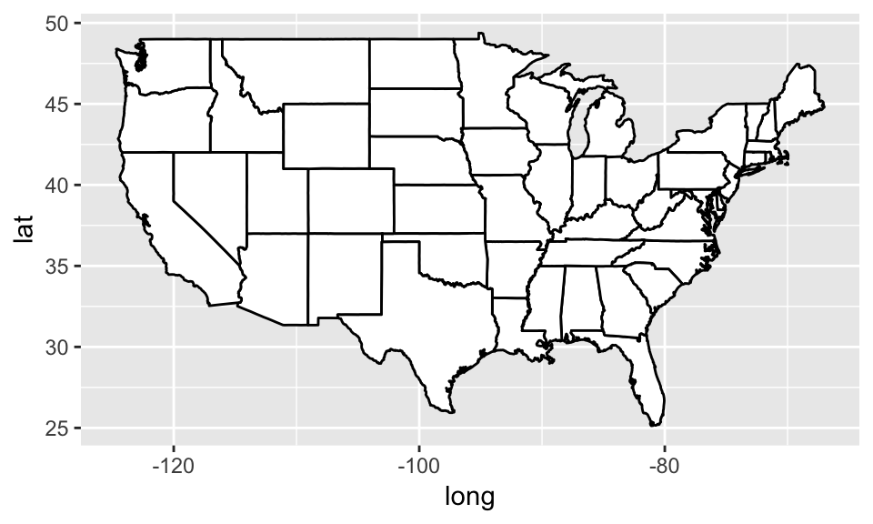

```r
ggplot(statesMap, aes(x = long, y = lat, group = group)) + geom_polygon(fill = "white", color = "black")
```

Create a new variable called region with the lowercase names to match the statesMap

```r
murders$region = tolower(murders$State)
```

Join the statesMap data and the murders data into one dataframe

```r
murderMap = merge(statesMap, murders, by="region")
str(murderMap)
```

```
## 'data.frame':    15537 obs. of  12 variables:
##  $ region           : chr  "alabama" "alabama" "alabama" "alabama" ...
##  $ long             : num  -87.5 -87.5 -87.5 -87.5 -87.6 ...
##  $ lat              : num  30.4 30.4 30.4 30.3 30.3 ...
##  $ group            : num  1 1 1 1 1 1 1 1 1 1 ...
##  $ order            : int  1 2 3 4 5 6 7 8 9 10 ...
##  $ subregion        : chr  NA NA NA NA ...
##  $ State            : Factor w/ 51 levels "Alabama","Alaska",..: 1 1 1 1 1 1 1 1 1 1 ...
##  $ Population       : int  4779736 4779736 4779736 4779736 4779736 4779736 4779736 4779736 4779736 4779736 ...
##  $ PopulationDensity: num  94.7 94.7 94.7 94.7 94.7 ...
##  $ Murders          : int  199 199 199 199 199 199 199 199 199 199 ...
##  $ GunMurders       : int  135 135 135 135 135 135 135 135 135 135 ...
##  $ GunOwnership     : num  0.517 0.517 0.517 0.517 0.517 0.517 0.517 0.517 0.517 0.517 ...
```

Plot the number of murder on our map of the United States

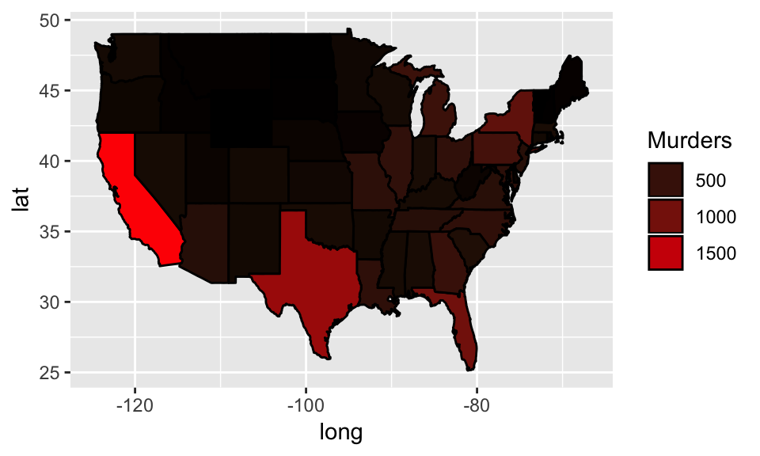

```r
ggplot(murderMap, aes(x = long, y = lat, group = group, fill = Murders)) + geom_polygon(color = "black") + scale_fill_gradient(low = "black", high = "red", guide = "legend")
```

Plot a map of the population

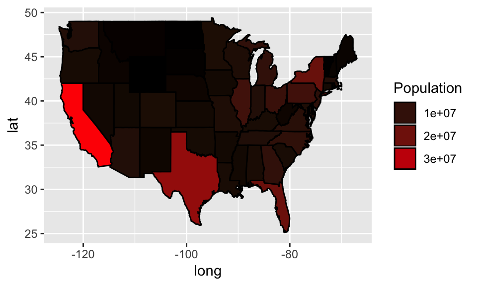

```r
ggplot(murderMap, aes(x = long, y = lat, group = group, fill = Population)) + geom_polygon(color = "black") + scale_fill_gradient(low = "black", high = "red", guide = "legend")
```

Create a new variable that is the number of murders per 100,000 population

```r
murderMap$MurderRate = murderMap$Murders / murderMap$Population * 100000
```

Redo our plot with murder rate

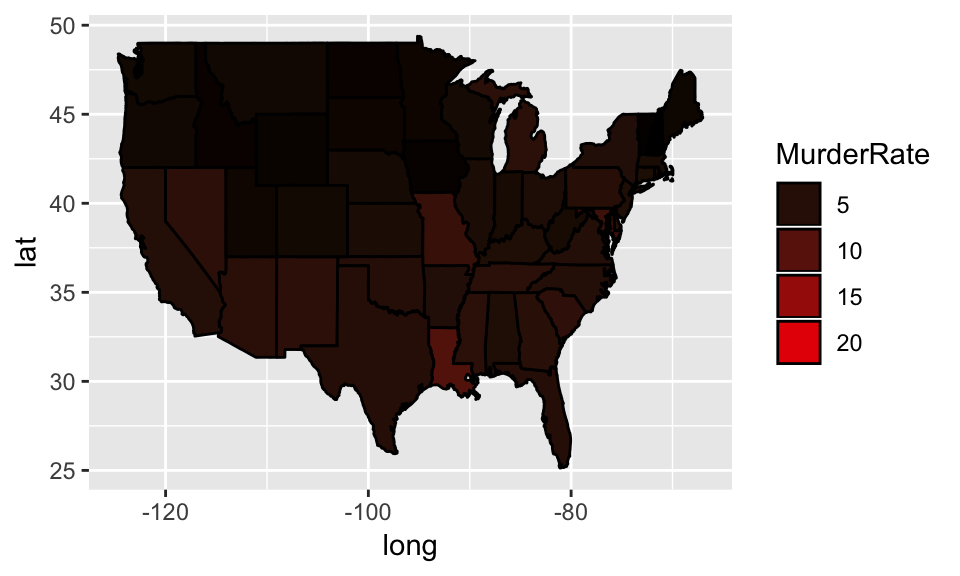

```r
ggplot(murderMap, aes(x = long, y = lat, group = group, fill = MurderRate)) + geom_polygon(color = "black") + scale_fill_gradient(low = "black", high = "red", guide = "legend")
```

Redo the plot, removing any states with murder rates above 10:

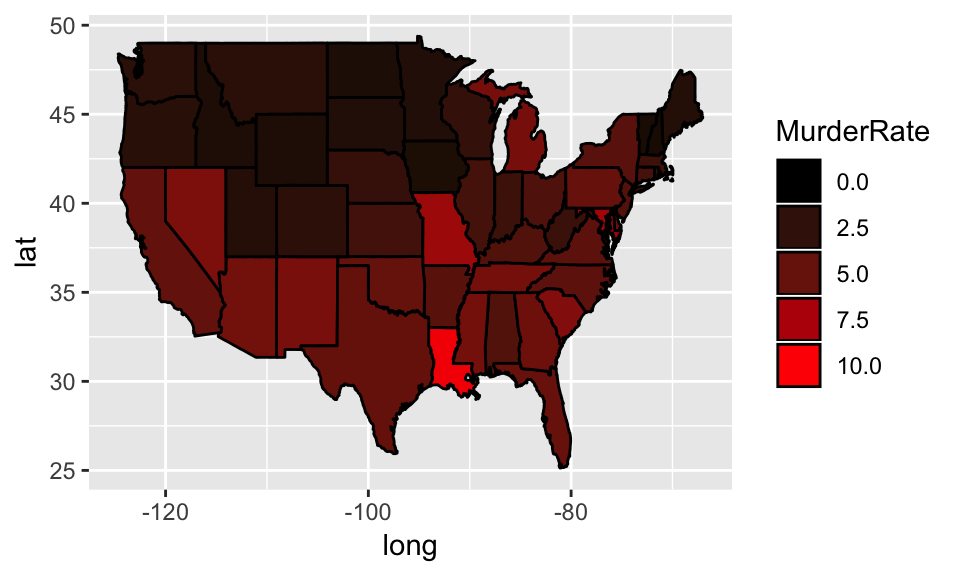

```r
ggplot(murderMap, aes(x = long, y = lat, group = group, fill = MurderRate)) + geom_polygon(color = "black") + scale_fill_gradient(low = "black", high = "red", guide = "legend", limits = c(0,10))
```

#### Quick Question

```r
library(dplyr)
murderMap %>% group_by(region) %>% summarise(x = mean(GunOwnership)) %>% arrange(desc(x))
```

```
## # A tibble: 49 x 2
##    region            x
##    <chr>         <dbl>
##  1 wyoming       0.597
##  2 montana       0.577
##  3 south dakota  0.566
##  4 west virginia 0.554
##  5 arkansas      0.553
##  6 idaho         0.553
##  7 mississippi   0.553
##  8 alabama       0.517
##  9 north dakota  0.507
## 10 kentucky      0.477
## # … with 39 more rows
```